# Ischemia Reperfusion in Human Cardiac Endothelium

Connor W Lantz

2026-08-03

# Summary

This study examines single-nucleus RNA sequencing (snRNA-seq) data from the left ventricle of human donor hearts subjected to cold static storage in histidine-tryptophan-ketoglutarate (HTK) solution, with tissue sampled at three timepoints: **Baseline** (immediately after procurement), **10h** of cold storage, and **Perfused** (following reperfusion). Data were obtained from [Lei et al., *Nature Cardiovascular Research* (2025)](https://doi.org/10.1038/s44161-025-00653-x), deposited under GEO accession GSE261124.

The original study also profiled a parallel arm of hearts treated with **canrenone** (a mineralocorticoid receptor antagonist, labeled “CAN” in the raw metadata) to test whether blocking MR phase separation improves preservation outcomes. **This analysis is restricted to the untreated HTK arm only** (Baseline n = 3, 10h n = 3, Perfused n = 1); the canrenone-treated samples are excluded so that transcriptomic changes reflect cold storage/reperfusion alone, without a pharmacological intervention confounding the comparison.

## Analysis Overview

This report proceeds through the following stages, each corresponding to a major section below:

1. **Import & Subsetting** — build the Seurat object from the raw count matrix and isolate the HTK-only samples described above.
2. **Quality Control** — compute per-nucleus QC metrics, detect doublets (`scDblFinder`), and filter low-quality nuclei using a multi-criteria threshold.
3. **Normalization & Integration** — cell cycle scoring, `SCTransform` normalization (per sample), and Harmony batch correction (`IntegrateLayers`).
4. **Cell Annotations** — a resolution sweep and `clustree` analysis to choose a clustering resolution, followed by canonical-marker and unbiased marker-gene validation, and manual assignment of cell-type identities to each cluster.
5. **Endothelial Cells** — sub-clustering and re-analysis restricted to the three endothelial subtypes (Arterial, Microvascular, Venular).
6. **Differential Gene Expression** — pairwise MAST comparisons across storage/reperfusion timepoints within the Microvascular EC population.

Panel labels used throughout (e.g., “Figure 1A,” “Supplemental Figure 1C”) correspond directly to the figure/panel numbers referenced in the associated manuscript.

# Import Data

## Create Seurat Object from .h5 File

The raw filtered feature-barcode matrix (`GSM8135503`) was loaded and used to build a `Seurat` object, retaining genes detected in at least 3 cells and nuclei with at least 200 detected genes. Sample identity (`orig.ident`, values 1–15) was mapped to treatment group and storage solution based on the study’s sample sheet.

```r
### Read in .h5 file
data <- Read10X_h5("E:/NM_TRANSPLANT/Nadig_Jaishankar/snRNAseq/GSM8135503_filtered_feature_bc_matrix.h5")

### Create Seurat object
Cold_Preserve_Heart <- CreateSeuratObject(counts = data,
                                          min.cells = 3,
                                          names.delim = "-",
                                          names.field = 2,
                                          min.features = 200)

### Add Metadata
Idents(Cold_Preserve_Heart) <- "orig.ident"
Cold_Preserve_Heart <- RenameIdents(Cold_Preserve_Heart,
                                    "1" = "HTK Baseline",
                                    "2" = "HTK 10h",
                                    "3" = "HTK Baseline",
                                    "4" = "HTK 10h",
                                    "5" = "CAN Baseline",
                                    "6" = "CAN 10h",
                                    "7" = "CAN Baseline",
                                    "8" = "CAN 10h",
                                    "9" = "CAN Baseline",
                                    "10" = "CAN 10h",
                                    "11" = "HTK Baseline",
                                    "12" = "HTK 10h",
                                    "13" = "CAN Perfused",
                                    "14" = "HTK Perfused",
                                    "15" = "CAN Perfused")

Cold_Preserve_Heart$Treatment <- Idents(Cold_Preserve_Heart)
```

### Sample Summary Before Subsetting

The full dataset spans two preservation arms — untreated (HTK) and canrenone-treated (CAN) — across three timepoints each.

Samples Before Subsetting (All Treatments)

| Sample ID | Treatment | Number of Cells |
| --- | --- | --- |
| 1 | HTK Baseline | 1597 |
| 11 | HTK Baseline | 1185 |
| 3 | HTK Baseline | 635 |
| 12 | HTK 10h | 836 |
| 2 | HTK 10h | 1251 |
| 4 | HTK 10h | 324 |
| 5 | CAN Baseline | 2171 |
| 7 | CAN Baseline | 2020 |
| 9 | CAN Baseline | 747 |
| 10 | CAN 10h | 818 |
| 6 | CAN 10h | 1597 |
| 8 | CAN 10h | 548 |
| 13 | CAN Perfused | 1519 |
| 15 | CAN Perfused | 630 |
| 14 | HTK Perfused | 1245 |

### Subset Samples

Donor hearts preserved in **HTK** solution at Baseline (n = 3), after 10h of cold storage (n = 3), and after reperfusion (n = 1) are isolated for downstream analysis. The canrenone-treated (CAN) arm is excluded so that this analysis reflects cold storage/reperfusion biology alone (see Summary above).

```r
# Subset HTK Treatment Data
Cold_Preserve_Heart <- subset(Cold_Preserve_Heart, idents = c("HTK Baseline", "HTK 10h", "HTK Perfused"))

### Re-level Metadata Categories
Cold_Preserve_Heart$Treatment <- factor(Cold_Preserve_Heart$Treatment, levels = c("HTK Baseline", "HTK 10h", "HTK Perfused"))

Cold_Preserve_Heart$Sample_ID <- factor(Cold_Preserve_Heart$orig.ident, levels = c("1", "3", "11", "2", "4", "12", "14"))
```

### Sample Summary After Subsetting

Samples Retained After Subsetting (HTK Only)

| Sample ID | Treatment | Number of Cells |
| --- | --- | --- |
| 1 | HTK Baseline | 1597 |
| 11 | HTK Baseline | 1185 |
| 3 | HTK Baseline | 635 |
| 12 | HTK 10h | 836 |
| 2 | HTK 10h | 1251 |
| 4 | HTK 10h | 324 |
| 14 | HTK Perfused | 1245 |

Note: Only HTK Baseline, HTK 10h, and HTK Perfused samples retained for downstream analysis.

# Quality Control

## Calculating QC Metrics

Standard per-nucleus QC metrics are computed: the novelty score (unique genes detected per UMI, a proxy for library complexity), and the percentage of reads mapping to mitochondrial, ribosomal, and hemoglobin genes. Because this is single-**nucleus** (not single-cell) RNA-seq, cytoplasmic mitochondrial transcripts should already be largely excluded during nuclear isolation — so an elevated `mitoRatio` here is more indicative of ambient/cytoplasmic contamination than of dying cells, and stricter thresholds than typical scRNA-seq QC are applied later.

```r
# Log Normalization metrics
Cold_Preserve_Heart$log10GenesPerUMI <- log10(Cold_Preserve_Heart$nFeature_RNA) / log10(Cold_Preserve_Heart$nCount_RNA)

### Mitochondrial
Cold_Preserve_Heart <- PercentageFeatureSet(Cold_Preserve_Heart, pattern = "^MT-", col.name = "mitoRatio")

### Ribosomal
Cold_Preserve_Heart <- PercentageFeatureSet(Cold_Preserve_Heart, pattern = "^RP[LS]", col.name = "riboRatio")

### Hemoglobin
hemo_genes <- grep("^HBA1$|^HBA2$|^HBB$|^HBD$", rownames(Cold_Preserve_Heart), value = TRUE)
Cold_Preserve_Heart <- PercentageFeatureSet(Cold_Preserve_Heart, features = hemo_genes, col.name = "hemoRatio")
```

Average QC Metrics by Sample

| Sample ID | Treatment | Genes/Cell | UMIs/Cell | log10(Genes/UMI) | % Mito | % Ribo | % Hemo |
| --- | --- | --- | --- | --- | --- | --- | --- |
| 1 | HTK Baseline | 2023 | 5454 | 0.920 | 3.29 | 0 | 0.00 |
| 3 | HTK Baseline | 1321 | 2641 | 0.946 | 0.92 | 0 | 0.00 |
| 11 | HTK Baseline | 1659 | 3502 | 0.933 | 1.10 | 0 | 0.00 |
| 2 | HTK 10h | 2039 | 6813 | 0.912 | 3.77 | 0 | 0.00 |
| 4 | HTK 10h | 1627 | 3804 | 0.937 | 2.16 | 0 | 0.00 |
| 12 | HTK 10h | 1481 | 3165 | 0.937 | 4.27 | 0 | 0.00 |
| 14 | HTK Perfused | 1017 | 1866 | 0.940 | 2.45 | 0 | 0.02 |

Note: Values represent per-sample means across all nuclei prior to QC filtering.

## Calculate Doublets

The [**scDblFinder**](https://github.com/plger/scDblFinder) package gathers various methods for the detection and handling of doublets/multiplets in single-cell sequencing data (i.e., multiple nuclei captured within the same droplet or reaction volume), including the `scDblFinder` method used here. Doublet detection is run **per sample** (`samples = "orig.ident"`) since doublet rates depend on loading concentration and cell recovery, which vary across samples.

scDblFinder Doublet Classification by Sample

| Sample ID | Treatment | Singlets | Doublets | % Doublets |
| --- | --- | --- | --- | --- |
| 1 | HTK Baseline | 1528 | 69 | 4.32 |
| 3 | HTK Baseline | 615 | 20 | 3.15 |
| 11 | HTK Baseline | 1139 | 46 | 3.88 |
| 2 | HTK 10h | 1204 | 47 | 3.76 |
| 4 | HTK 10h | 315 | 9 | 2.78 |
| 12 | HTK 10h | 809 | 27 | 3.23 |
| 14 | HTK Perfused | 1201 | 44 | 3.53 |

## QC Metrics

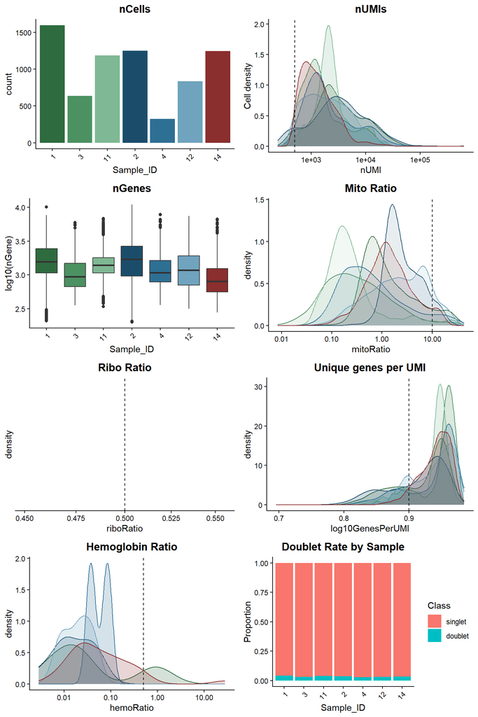

```r
### Create Metadata Slot in Merged Seurat
metadata <- Cold_Preserve_Heart@meta.data
metadata$cells <- rownames(metadata)
metadata <- metadata %>%
  dplyr::rename(seq_folder = orig.ident,
                nUMI = nCount_RNA,
                nGene = nFeature_RNA)

#nCells
p1 <- metadata %>%
  ggplot(aes(x=Sample_ID, fill=Sample_ID)) +
  geom_bar() +
  scale_fill_manual(values = sample_id_colors) +
  theme_classic() +
  theme(axis.text.x = element_text(angle = 45, vjust = 1, hjust=1)) +
  theme(plot.title = element_text(hjust=0.5, face="bold")) +
  ggtitle("nCells") +
  NoLegend()

#nUMIs
p2 <- metadata %>%
  ggplot(aes(color = Sample_ID, x = nUMI, fill = Sample_ID)) +
  geom_density(alpha = 0.2) +
  scale_x_log10() +
  scale_color_manual(values = sample_id_colors) +
  scale_fill_manual(values = sample_id_colors) +
  theme_classic() +
  ylab("Cell density") +
  geom_vline(xintercept = 500, linetype = "dashed") +
  theme(plot.title = element_text(hjust=0.5, face="bold")) +
  ggtitle("nUMIs") +
  NoLegend()

#nGenes
p3 <- metadata %>%
  ggplot(aes(x=Sample_ID, y=log10(nGene), fill=Sample_ID)) +
  geom_boxplot() +
  scale_fill_manual(values = sample_id_colors) +
  theme_classic() +
  theme(axis.text.x = element_text(angle = 45, vjust = 1, hjust=1)) +
  theme(plot.title = element_text(hjust=0.5, face="bold")) +
  ggtitle("nGenes") +
  NoLegend()

#mito counts ratio
p4 <- metadata %>%
  ggplot(aes(color=Sample_ID, x=mitoRatio, fill=Sample_ID)) +
  geom_density(alpha = 0.1) +
  scale_x_log10() +
  scale_color_manual(values = sample_id_colors) +
  scale_fill_manual(values = sample_id_colors) +
  theme_classic() +
  geom_vline(xintercept = 10, linetype = "dashed") +
  theme(plot.title = element_text(hjust=0.5, face="bold")) +
  ggtitle("Mito Ratio") +
  NoLegend()

#ribo counts ratio
p5 <- metadata %>%
  ggplot(aes(color=Sample_ID, x=riboRatio, fill=Sample_ID)) +
  geom_density(alpha = 0.2) +
  scale_x_log10() +
  scale_color_manual(values = sample_id_colors) +
  scale_fill_manual(values = sample_id_colors) +
  theme_classic() +
  geom_vline(xintercept = 0.5, linetype = "dashed") +
  theme(plot.title = element_text(hjust=0.5, face="bold")) +
  ggtitle("Ribo Ratio") +
  NoLegend()

#novelty gene
p6 <- metadata %>%
  ggplot(aes(x=log10GenesPerUMI, color = Sample_ID, fill=Sample_ID)) +
  geom_density(alpha = 0.2) +
  scale_color_manual(values = sample_id_colors) +
  scale_fill_manual(values = sample_id_colors) +
  theme_classic() +
  geom_vline(xintercept = 0.9, linetype = "dashed") +
  theme(plot.title = element_text(hjust=0.5, face="bold")) +
  ggtitle("Unique genes per UMI") +
  NoLegend()

# Hemoglobin ratio by sample — check for elevated blood contamination
p7 <- metadata %>%
  ggplot(aes(color = Sample_ID, x = hemoRatio, fill = Sample_ID)) +
  geom_density(alpha = 0.2) +
  scale_x_log10() +
  scale_color_manual(values = sample_id_colors) +
  scale_fill_manual(values = sample_id_colors) +
  theme_classic() +
  geom_vline(xintercept = 0.5, linetype = "dashed") +
  theme(plot.title = element_text(hjust = 0.5, face = "bold")) +
  ggtitle("Hemoglobin Ratio") +
  NoLegend()

# Doublet rate by sample
p8 <- metadata %>%
  ggplot(aes(x = Sample_ID, fill = scDblFinder.class)) +
  geom_bar(position = "fill") +
  theme_classic() +
  theme(axis.text.x = element_text(angle = 45, vjust = 1, hjust = 1)) +
  theme(plot.title = element_text(hjust = 0.5, face = "bold")) +
  ylab("Proportion") +
  ggtitle("Doublet Rate by Sample") +
  labs(fill = "Class")

grid.arrange(p1, p2, p3, p4, p5, p6, p7, p8, ncol = 2)
```

## Filtering Cells Based on QC

Putting the above together, a nucleus is retained only if it passes **all** of the following criteria simultaneously:

| Criterion | Threshold | Rationale |
| --- | --- | --- |
| Novelty score (`log10GenesPerUMI`) | > 0.90 | Excludes low-complexity droplets (e.g., empty droplets, ambient RNA) |
| UMI count (`nCount_RNA`) | > 500 | Excludes droplets with insufficient sequencing depth |
| Genes detected (`nFeature_RNA`) | > 250 | Excludes low-complexity or poorly captured nuclei |
| Mitochondrial content (`mitoRatio`) | < 10% | Excludes dying/damaged cells or cytoplasmic contamination (stricter than typical scRNA-seq given nuclear enrichment) |
| Hemoglobin content (`hemoRatio`) | < 0.5% | Excludes ambient blood/erythrocyte contamination |
| Doublet classification | `scDblFinder` singlet only | Excludes multiplets called per-sample |

This is a fairly stringent, multi-criteria filter by design, since it needs to simultaneously exclude empty droplets/low-complexity nuclei, dying (high-mito) cells, blood contamination, and doublets, across samples with different sequencing depths and cell recovery.

```r
### Subset high-quality cells on QC metrics determined above
Cold_Preserve_Heart_filtered <- subset(
  x = Cold_Preserve_Heart,
  (log10GenesPerUMI > 0.90) &
    (nCount_RNA > 500) &
    (nFeature_RNA > 250) &
    (mitoRatio < 10) &
    (hemoRatio < 0.5) &
    (scDblFinder.class == "singlet")
)

### Build before/after filtering summary table
pre_filter_n <- table(Cold_Preserve_Heart$Sample_ID)
post_filter_n <- table(Cold_Preserve_Heart_filtered$Sample_ID)

filter_tbl <- data.frame(
  Sample_ID = names(pre_filter_n),
  Treatment = Cold_Preserve_Heart$Treatment[match(names(pre_filter_n), Cold_Preserve_Heart$Sample_ID)],
  Before = as.integer(pre_filter_n),
  After = as.integer(post_filter_n[names(pre_filter_n)]),
  row.names = NULL
) %>%
  mutate(
    Removed = Before - After,
    Percent_Retained = round(100 * After / Before, 1)
  ) %>%
  arrange(Treatment, Sample_ID)
```

Cell Counts Before and After QC Filtering

| Sample ID | Treatment | Cell Counts Before Filtering | Cell Counts After Filtering | Cell Counts Removed | % Retained |
| --- | --- | --- | --- | --- | --- |
| 1 | HTK Baseline | 1597 | 1015 | 582 | 63.6 |
| 11 | HTK Baseline | 1185 | 934 | 251 | 78.8 |
| 3 | HTK Baseline | 635 | 527 | 108 | 83.0 |
| 12 | HTK 10h | 836 | 612 | 224 | 73.2 |
| 2 | HTK 10h | 1251 | 739 | 512 | 59.1 |
| 4 | HTK 10h | 324 | 243 | 81 | 75.0 |
| 14 | HTK Perfused | 1245 | 1091 | 154 | 87.6 |

Summary: Total: 7073 nuclei before filtering → 5161 nuclei after filtering (73% retained overall).

# Normalization and Integration

## Cell Cycle Scoring

Cell cycle phase was scored for each nucleus using the canonical S-phase and G2/M-phase marker gene sets from Tirosh et al. (2015), as implemented in Seurat’s `CellCycleScoring()`. The difference between S and G2/M scores (`CC.Difference`) is retained for regression of proliferation-driven variance during normalization (see SCTransform below).

### Plot

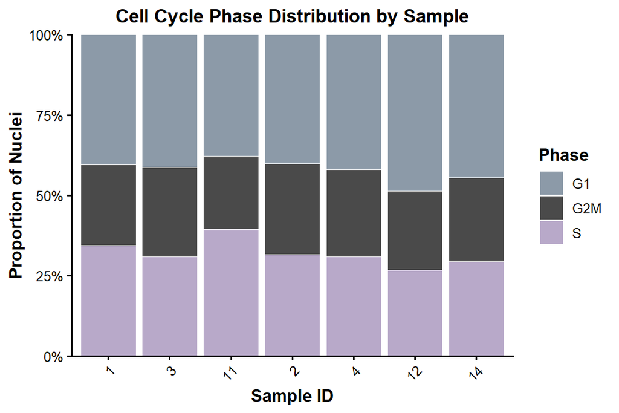

```r
phase_colors <- c(
  "G1"  = "#8C9AA8",   # slate gray-blue
  "S"   = "#B8A9C9",   # muted lavender
  "G2M" = "#4A4A4A"    # dark matte gray (consistent with table headers)
)

plot_cell_cycle <- Cold_Preserve_Heart_filtered@meta.data %>%
  ggplot(aes(x = Sample_ID, fill = Phase)) +
  geom_bar(position = "fill", color = "white", linewidth = 0.3) +
  scale_fill_manual(values = phase_colors, name = "Phase") +
  scale_y_continuous(labels = scales::percent_format(), expand = c(0, 0)) +
  labs(
    title = "Cell Cycle Phase Distribution by Sample",
    x = "Sample ID",
    y = "Proportion of Nuclei"
  ) +
  theme_classic(base_size = 12) +
  theme(
    plot.title = element_text(hjust = 0.5, face = "bold", size = 13),
    axis.text.x = element_text(angle = 45, vjust = 1, hjust = 1),
    axis.title = element_text(face = "bold"),
    legend.title = element_text(face = "bold"),
    legend.position = "right",
    panel.grid = element_blank()
  )

plot_cell_cycle
```

### Table

```r
cc_tbl <- Cold_Preserve_Heart_filtered@meta.data %>%
  group_by(Sample_ID, Treatment, Phase) %>%
  summarise(nCells = n(), .groups = "drop") %>%
  group_by(Sample_ID) %>%
  mutate(Percent = round(100 * nCells / sum(nCells), 1)) %>%
  ungroup() %>%
  tidyr::pivot_wider(
    id_cols = c(Sample_ID, Treatment),
    names_from = Phase,
    values_from = c(nCells, Percent),
    values_fill = 0
  ) %>%
  select(Sample_ID, Treatment,
         nCells_G1, Percent_G1,
         nCells_S, Percent_S,
         nCells_G2M, Percent_G2M) %>%
  arrange(Treatment, Sample_ID)

cc_tbl %>%
  kbl(caption = "Cell Cycle Phase Distribution by Sample",
      col.names = c("Sample ID", "Treatment", "n", "%", "n", "%", "n", "%"),
      align = "c",
      row.names = FALSE) %>%
  kable_styling(bootstrap_options = c("striped", "hover", "condensed"),
                full_width = FALSE, position = "left") %>%
  row_spec(0, bold = TRUE, color = "white", background = "#4A4A4A") %>%
  add_header_above(c(" " = 2, "G1" = 2, "S" = 2, "G2/M" = 2)) %>%
  footnote(
    general = "Percentages reflect the proportion of each cell cycle phase within each sample (rows sum to 100%).",
    general_title = "Note: ", footnote_as_chunk = TRUE
  )
```

Cell Cycle Phase Distribution by Sample

| Sample ID | Treatment | G1 n | G1 % | S n | S % | G2/M n | G2/M % |
| --- | --- | --- | --- | --- | --- | --- | --- |
| 1 | HTK Baseline | 411 | 40.5 | 350 | 34.5 | 254 | 25.0 |
| 3 | HTK Baseline | 218 | 41.4 | 163 | 30.9 | 146 | 27.7 |
| 11 | HTK Baseline | 353 | 37.8 | 369 | 39.5 | 212 | 22.7 |
| 2 | HTK 10h | 297 | 40.2 | 234 | 31.7 | 208 | 28.1 |
| 4 | HTK 10h | 102 | 42.0 | 75 | 30.9 | 66 | 27.2 |
| 12 | HTK 10h | 298 | 48.7 | 164 | 26.8 | 150 | 24.5 |
| 14 | HTK Perfused | 486 | 44.5 | 321 | 29.4 | 284 | 26.0 |

Note: Percentages reflect the proportion of each cell cycle phase within each sample (rows sum to 100%).

## SCTransform Normalization

Following QC filtering and cell cycle scoring, the RNA assay was split by sample (`Sample_ID`) prior to normalization, so that each sample’s counts are modeled independently — this is required for the downstream Harmony integration step (`IntegrateLayers`), which corrects for sample-level batch effects across separately normalized layers. [**SCTransform**](https://satijalab.org/seurat/articles/sctransform_vignette) (v2 regularization) was applied to each sample layer, regressing out mitochondrial content (`mitoRatio`) and the S/G2M score difference (`CC.Difference`) to remove technical and cell-cycle-associated variance ahead of dimensionality reduction and clustering.

## Harmony Integration of Normalized Datasets

### Assessment of Batch Effects Before Correction

PCA is run on the SCT-normalized data and an elbow plot inspected to gauge how many PCs capture meaningful variance. This “before” UMAP (computed prior to integration) is the baseline against which the post-Harmony integration is compared in the next step.

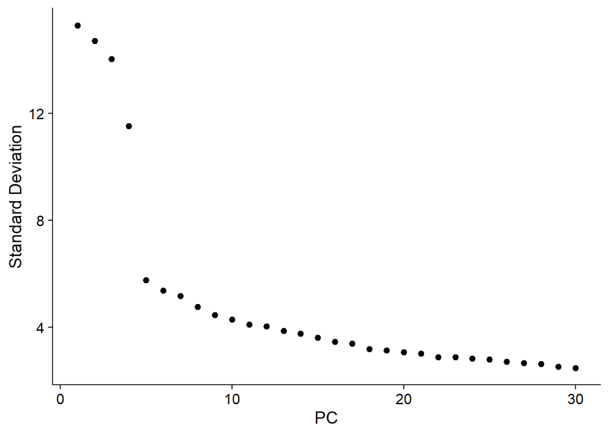

```r
DefaultAssay(Cold_Preserve_Heart_filtered) <- "SCT"
Cold_Preserve_Heart_filtered <- RunPCA(Cold_Preserve_Heart_filtered, npcs = 30, verbose = FALSE)

# Check how much separation exists by sample/condition before integration --
# this is the "before" picture to compare against post-integration
ElbowPlot(Cold_Preserve_Heart_filtered, ndims = 30)
```

```r
Cold_Preserve_Heart_filtered <- RunUMAP(Cold_Preserve_Heart_filtered, dims = 1:30, reduction = "pca", reduction.name = "umap.unintegrated")
```

#### Sample ID

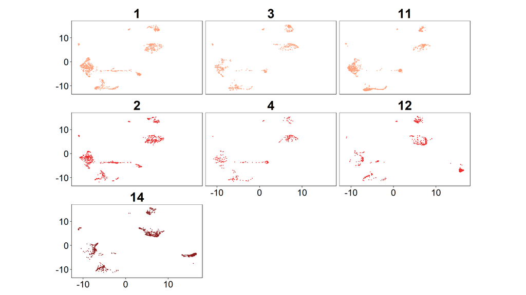

```r
DimPlot(Cold_Preserve_Heart_filtered,
        reduction = "umap.unintegrated",
        split.by = "Sample_ID",
        cols = treatment_colors,
        ncol = 3) +
  NoLegend() +
    theme(
      aspect.ratio = 9/16,
      strip.text = element_text(
        hjust = 0.5,
        face = "bold",
        size = 28,
        color = "black"
      ),
      panel.border = element_rect(
        color = "black",
        fill = NA,
        linewidth = 0.4
      ),
      axis.title = element_blank(),
      axis.text = element_text(
        size = 20,
        color = "black"
      )
    )
```

#### Treatment

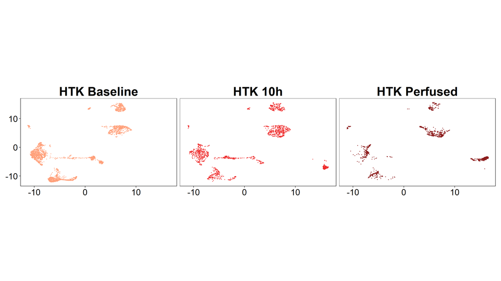

```r
DimPlot(Cold_Preserve_Heart_filtered,
        reduction = "umap.unintegrated",
        split.by = "Treatment",
        cols = treatment_colors) +
  NoLegend() +
    theme(
      aspect.ratio = 9/16,
      strip.text = element_text(
        hjust = 0.5,
        face = "bold",
        size = 28,
        color = "black"
      ),
      panel.border = element_rect(
        color = "black",
        fill = NA,
        linewidth = 0.4
      ),
      axis.title = element_blank(),
      axis.text = element_text(
        size = 20,
        color = "black"
      )
    )
```

### Perform Integration on SCTransform-Normalized Data

[**Harmony**](https://github.com/immunogenomics/harmony) (via Seurat v5’s `IntegrateLayers`) is used to correct for sample/batch effects across the 7 samples while operating on the SCT-normalized values, producing a new `harmony` reduction. A UMAP is recomputed on the Harmony-corrected embedding and split by sample and by treatment; the goal is to confirm that nuclei now mix across samples/conditions within a given cell type rather than separating by batch, which would indicate residual, uncorrected technical variation.

#### Sample ID

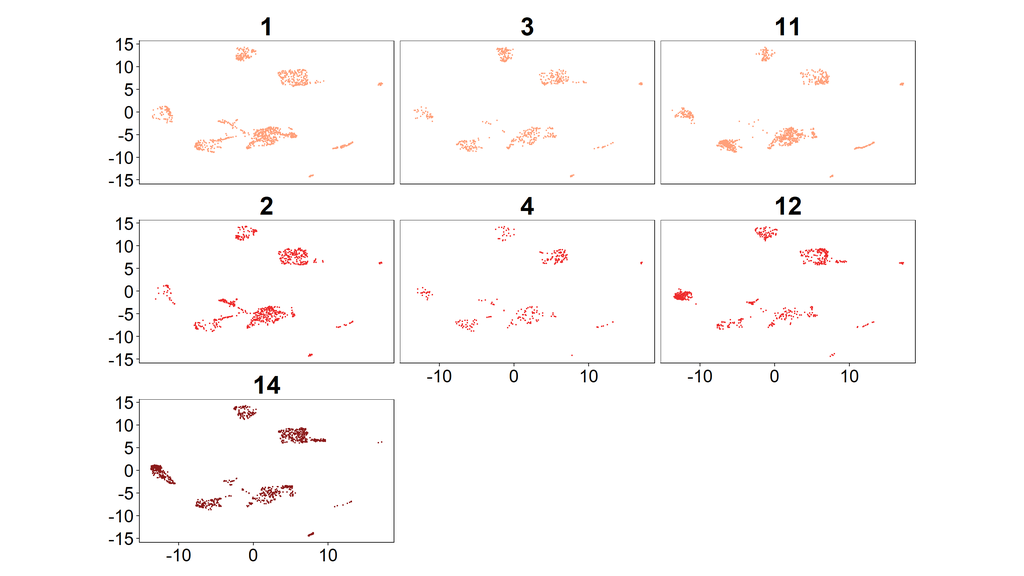

```r
DimPlot(Cold_Preserve_Heart_filtered,
        reduction = "umap.integrated",
        split.by = "Sample_ID",
        cols = treatment_colors,
        ncol = 3) +
  NoLegend() +
    theme(
      aspect.ratio = 9/16,
      strip.text = element_text(
        hjust = 0.5,
        face = "bold",
        size = 28,
        color = "black"
      ),
      panel.border = element_rect(
        color = "black",
        fill = NA,
        linewidth = 0.4
      ),
      axis.title = element_blank(),
      axis.text = element_text(
        size = 20,
        color = "black"
      )
    )
```

#### Treatment

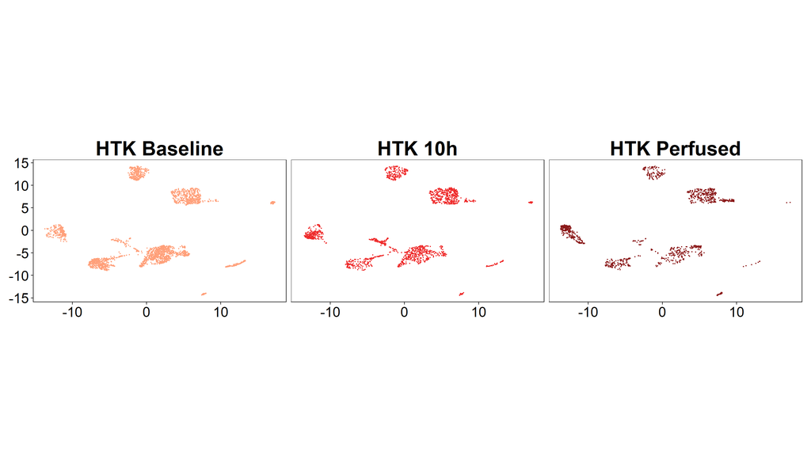

```r
DimPlot(Cold_Preserve_Heart_filtered,
        reduction = "umap.integrated",
        split.by = "Treatment",
        cols = treatment_colors) +
  NoLegend() +
    theme(
      aspect.ratio = 9/16,
      strip.text = element_text(
        hjust = 0.5,
        face = "bold",
        size = 28,
        color = "black"
      ),
      panel.border = element_rect(
        color = "black",
        fill = NA,
        linewidth = 0.4
      ),
      axis.title = element_blank(),
      axis.text = element_text(
        size = 20,
        color = "black"
      )
    )
```

# Cell Annotations

## Optimal Resolution for Clustering

### Resolutions Tested

Rather than committing to a single clustering resolution up front, `FindClusters` is run across a sweep from 0.1 to 1.0 (in steps of 0.1) on the Harmony neighbor graph. Seurat stores each result as its own metadata column (e.g. `SCT_snn_res.0.6`) instead of overwriting, which lets every resolution be inspected/compared before one is chosen for annotation.

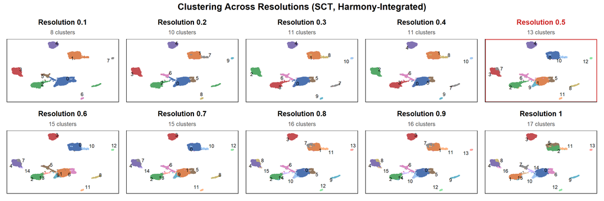

```r
chosen_res <- 0.5

res_dimplots <- lapply(resolutions, function(res) {
  col <- paste0("SCT_snn_res.", res)
  n_clusters <- nlevels(factor(Cold_Preserve_Heart_filtered@meta.data[[col]]))
  is_chosen <- res == chosen_res

  DimPlot(
    Cold_Preserve_Heart_filtered,
    reduction = "umap.integrated",
    group.by = col,
    pt.size = 0.4,
    label = TRUE,
    label.size = 3,
    label.color = "black",
    cols = cluster_colors,
    repel = TRUE
  ) +
    ggtitle(paste0("Resolution ", res),
            subtitle = paste0(n_clusters, " clusters")) +
    NoLegend() +
    theme(
      aspect.ratio = 9/16,
      plot.title = element_text(
        hjust = 0.5, face = "bold", size = 13,
        color = if (is_chosen) "firebrick3" else "black"
      ),
      plot.subtitle = element_text(hjust = 0.5, size = 10, color = "grey30"),
      panel.border = element_rect(
        color = if (is_chosen) "firebrick3" else "black",
        fill = NA,
        linewidth = if (is_chosen) 1 else 0.4
      ),
      axis.title = element_blank(),
      axis.text = element_blank(),
      axis.ticks = element_blank()
    )
})

wrap_plots(res_dimplots, ncol = 5) +
  plot_annotation(
    title = "Clustering Across Resolutions (SCT, Harmony-Integrated)",
    theme = theme(plot.title = element_text(hjust = 0.5, face = "bold", size = 16))
  )
```

### Clustering Tree of resolutions between 0-1

A `clustree` plot visualizes how clusters split and merge as resolution increases, which is a more principled way to pick a working resolution than eyeballing UMAPs alone: it highlights where a resolution increase adds a genuinely new, stable branch versus where it just fragments an existing population. Resolution **0.5** was chosen here (boxed) as the point that resolves the expected major immune/stromal/parenchymal populations without visibly over-splitting into unstable, low-cell-count clusters.

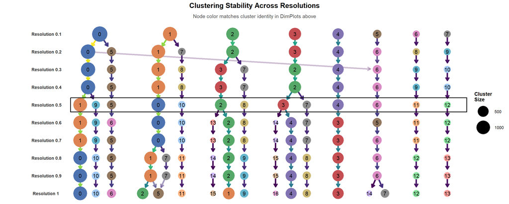

```r
Clustree_plot <- clustree(
  Cold_Preserve_Heart_filtered,
  prefix = "SCT_snn_res.",
  node_colour = "cluster",
  node_text_size = 4,
  edge_width = 1.5
) +
  guides(edge_alpha = "none", edge_colour = "none", colour = "none") +
  scale_colour_manual(values = cluster_colors, name = "Cluster") +
  scale_size(name = "Cluster\nSize", range = c(5, 15)) +
  ggtitle("Clustering Stability Across Resolutions",
          subtitle = "Node color matches cluster identity in DimPlots above") +
  theme(
    plot.title = element_text(hjust = 0.5, face = "bold", size = 15),
    plot.subtitle = element_text(hjust = 0.5, size = 11, color = "grey30"),
    legend.position = "right",
    legend.title = element_text(face = "bold")
  )

### Pull node layout data for row labels + resolution highlight
res_col <- "SCT_snn_res."   # matches the `prefix` argument above
node_data <- Clustree_plot$data

### Build one label per resolution row, positioned left of the leftmost node
row_label_df <- node_data %>%
  distinct(.data[[res_col]], y) %>%
  arrange(y) %>%
  mutate(label = paste0("Resolution ", format(.data[[res_col]], nsmall = 1)))

left_edge <- min(node_data$x) - 1.2   # padding so labels don't overlap nodes

Clustree_plot <- Clustree_plot +
  geom_text(
    data = row_label_df,
    aes(x = left_edge, y = y, label = label),
    inherit.aes = FALSE,
    hjust = 1, fontface = "bold", size = 3.3, color = "grey20"
  ) +
  coord_cartesian(clip = "off") +
  theme(plot.margin = margin(5.5, 5.5, 5.5, 90))

### Highlight the chosen resolution row (kept from before)
chosen_res <- 0.5
y_range <- range(node_data$y[node_data[[res_col]] == chosen_res], na.rm = TRUE)

Clustree_plot <- Clustree_plot +
  annotate("rect",
           xmin = -11, xmax = Inf,
           ymin = y_range[1] - 0.4, ymax = y_range[2] + 0.4,
           fill = "white", alpha = 0.02, color = "gray5", linewidth = 0.8)

Clustree_plot
```

### Clustering trees with nodes colored by canonical marker expression

As a second check on the resolution choice, the same clustree layout is recolored by mean expression of canonical lineage markers. A good resolution should show each canonical marker “lighting up” a distinct, coherent branch rather than being smeared across multiple unrelated branches.

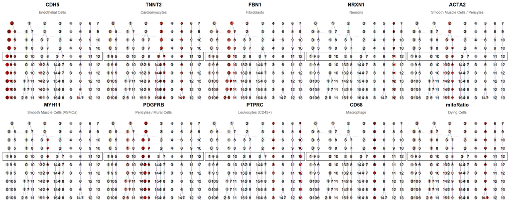

```r
markers_to_check <- c(
  "CDH5", # Endothelial Cells
  "TNNT2", # Cardiomyocytes
  "FBN1", # Fibroblasts
  "NRXN1", # Neurons
  "ACTA2", # Smooth Muscle Cells/Pericytes
  "MYH11", # VSMCs
  "PDGFRB", # Pericytes
  "PTPRC",
  "CD68",
  "mitoRatio"
)

# Canonical cell-type identity for each marker, used to label each panel
marker_cell_types <- c(
  "CDH5"   = "Endothelial Cells",
  "TNNT2"  = "Cardiomyocytes",
  "FBN1"   = "Fibroblasts",
  "NRXN1"  = "Neurons",
  "ACTA2"  = "Smooth Muscle Cells / Pericytes",
  "MYH11"  = "Smooth Muscle Cells (VSMCs)",
  "PDGFRB" = "Pericytes / Mural Cells",
  "PTPRC"  = "Leukocytes (CD45+)",
  "CD68" = "Macrophage",
  "mitoRatio"  = "Dying Cells"
)

# Build one small clustree per marker, stripped down for a compact multi-panel layout
make_marker_clustree <- function(gene) {
  clustree(
    Cold_Preserve_Heart_filtered,
    prefix = "SCT_snn_res.",
    node_colour = gene,
    node_colour_aggr = "mean",
    exprs = "data",
    node_size_range = c(2, 5),
    node_text_size = 4,
    edge_width = 0.25
  ) +
    scale_color_gradient(low = "gray75", high = "firebrick", name = "Mean\nExpression") +
    ggtitle(gene, subtitle = marker_cell_types[[gene]]) +
    annotate("rect",
           xmin = -Inf, xmax = Inf,
           ymin = which(resolutions == chosen_res) - 0.5,
           ymax = which(resolutions == chosen_res) + 0.5,
           fill = "white", alpha = 0.0, color = "gray5", linewidth = 0.5) +
    theme(
      legend.position = "none",
      plot.title = element_text(hjust = 0.5, face = "bold", size = 14),
      plot.subtitle = element_text(hjust = 0.5, size = 10, color = "grey30"),
      axis.title = element_blank(),
      axis.text = element_blank(),
      axis.ticks = element_blank()
    )
}

marker_plots <- lapply(markers_to_check, make_marker_clustree)
names(marker_plots) <- markers_to_check

# Arrange as a 2x4 grid, matching the reference figure's two rows of four
wrap_plots(marker_plots, ncol = 5)
```

### UMAPs of Marker Expression

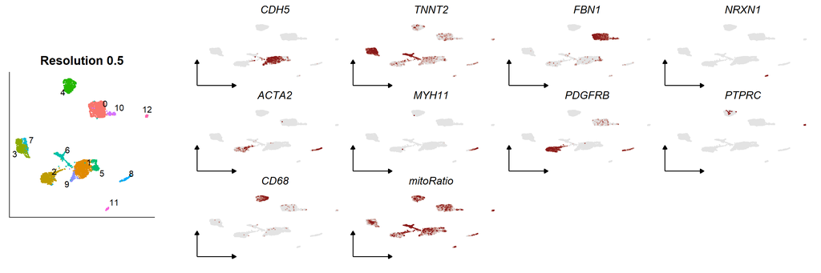

```r
# --- Left panel: DimPlot at resolution 0.6, square, spanning both rows ---
DimPlot_res0.5 <- DimPlot(
  Cold_Preserve_Heart_filtered,
  reduction = "umap.integrated",
  group.by = "SCT_snn_res.0.5",
  label = TRUE,
  label.size = 4,
  repel = TRUE
) +
  ggtitle("Resolution 0.5") +
  theme(
    legend.position = "none",
    plot.title = element_text(hjust = 0.5, face = "bold", size = 16),
    axis.title = element_blank(),
    axis.text = element_blank(),
    axis.ticks = element_blank(),
    aspect.ratio = 1  # forces square panel
  )

# --- Right panel: your existing feature plot code, unchanged ---
DefaultAssay(Cold_Preserve_Heart_filtered) <- "SCT"

FeaturePlot_Cell_Markers <- FeaturePlot(Cold_Preserve_Heart_filtered,
                                        features = markers_to_check,
                                        reduction = "umap.integrated",
                                        order = T,
                                        cols = c("gray89", "firebrick4"),
                                        min.cutoff = ("q50"),
                                        max.cutoff = ("q95"),
                                        combine = F)

for(i in 1:length(FeaturePlot_Cell_Markers)) {
  FeaturePlot_Cell_Markers[[i]] <- FeaturePlot_Cell_Markers[[i]] +
  guides(color = guide_legend(override.aes = list(size=4), ncol=1)) +
  theme(plot.title = element_text(hjust = 0.5, face = "italic", size = rel(1)),
        axis.ticks = element_blank(), axis.text = element_blank(), axis.title = element_blank(), axis.line = element_blank()) +
  NoLegend()

  FeaturePlot_Cell_Markers[[i]] <-  ggdraw() +
  draw_plot(FeaturePlot_Cell_Markers[[i]]) +
  geom_segment(aes(x=0, y=0, xend=0.25, yend=0), arrow = arrow(length=unit(0.2, 'cm'), type = "closed")) +
  geom_segment(aes(x=0, y=0, xend=0, yend=0.3), arrow = arrow(length=unit(0.2, 'cm'), type = "closed"))
}

FeaturePlot_Cell_Markers_grid <- cowplot::plot_grid(plotlist = FeaturePlot_Cell_Markers, ncol = 4)

FeaturePlot_Cell_Markers_grid <- plot_grid(NULL, FeaturePlot_Cell_Markers_grid, NULL, NULL,
                                        nrow = 2,
                                        rel_widths = c(0.05, 0.95),
                                        rel_heights = c(0.94, 0.06))

# --- Combine: square DimPlot (30% width) on left, feature grid (70%) on right ---
combined_figure <- plot_grid(
  DimPlot_res0.5,
  FeaturePlot_Cell_Markers_grid,
  nrow = 1,
  rel_widths = c(0.2, 0.8)
)

combined_figure
```

### Find Markers to Identify Each Cluster

```r
DefaultAssay(Cold_Preserve_Heart_filtered) <- "SCT"
Idents(Cold_Preserve_Heart_filtered) <- "SCT_snn_res.0.5"

# Required before FindAllMarkers when working with SCT assay across multiple
# samples/models -- recalculates corrected counts so markers are comparable
# across clusters that may draw from different per-sample SCT models
Cold_Preserve_Heart_filtered <- PrepSCTFindMarkers(Cold_Preserve_Heart_filtered)

all_markers <- FindAllMarkers(
  Cold_Preserve_Heart_filtered,
  assay = "SCT",
  only.pos = TRUE,
  min.pct = 0.25,
  logfc.threshold = 0.25,
  verbose = TRUE
)

top_markers <- all_markers %>%
  group_by(cluster) %>%
  slice_max(order_by = avg_log2FC, n = 10) %>%
  ungroup() %>%
  select(cluster, gene, avg_log2FC, pct.1, pct.2, p_val_adj)

top_markers %>%
  mutate(
    avg_log2FC = round(avg_log2FC, 2),
    pct.1 = round(pct.1, 2),
    pct.2 = round(pct.2, 2),
    p_val_adj = formatC(p_val_adj, format = "e", digits = 2)
  ) %>%
  kbl(
    caption = "Top markers per cluster",
    col.names = c("Cluster", "Gene", "avg log2FC", "% expr (cluster)", "% expr (rest)", "Adj. p-value"),
    align = "clccccc"
  ) %>%
  kable_styling(
    bootstrap_options = c("striped", "hover", "condensed"),
    full_width = FALSE,
    font_size = 12
  ) %>%
  collapse_rows(columns = 1, valign = "top") %>%
  row_spec(0, bold = TRUE)
```

Top markers per cluster

| Cluster | Gene | avg log2FC | % expr (cluster) | % expr (rest) | Adj. p-value |
| --- | --- | --- | --- | --- | --- |
| 0 | VIT | 5.56 | 0.54 | 0.01 | 0.00e+00 |
|  | ACSM3 | 5.32 | 0.39 | 0.01 | 0.00e+00 |
|  | LUM | 5.08 | 0.43 | 0.02 | 0.00e+00 |
|  | SCARA5 | 5.04 | 0.54 | 0.03 | 0.00e+00 |
|  | PDGFRA | 4.91 | 0.49 | 0.02 | 0.00e+00 |
|  | MGST1 | 4.90 | 0.33 | 0.01 | 1.34e-255 |
|  | MFAP5 | 4.89 | 0.50 | 0.02 | 0.00e+00 |
|  | LTBP2 | 4.87 | 0.62 | 0.04 | 0.00e+00 |
|  | ABCA10 | 4.77 | 0.62 | 0.04 | 0.00e+00 |
|  | SERPINF1 | 4.68 | 0.82 | 0.05 | 0.00e+00 |
| 1 | CA4 | 5.38 | 0.34 | 0.01 | 2.15e-274 |
|  | CD300LG | 4.93 | 0.43 | 0.02 | 0.00e+00 |
|  | N4BP3 | 4.65 | 0.28 | 0.01 | 7.97e-205 |
|  | TNNT3 | 4.41 | 0.66 | 0.06 | 0.00e+00 |
|  | PRAG1 | 4.32 | 0.38 | 0.02 | 2.20e-263 |
|  | SYNE1 | 4.22 | 0.90 | 0.12 | 0.00e+00 |
|  | MCF2L | 4.17 | 0.90 | 0.09 | 0.00e+00 |
|  | RGCC | 4.16 | 0.57 | 0.05 | 0.00e+00 |
|  | GPIHBP1 | 4.14 | 0.43 | 0.03 | 1.79e-301 |
|  | LCN6 | 4.14 | 0.65 | 0.06 | 0.00e+00 |
| 2 | MUC3A | 8.15 | 0.84 | 0.01 | 0.00e+00 |
|  | AGAP2 | 7.29 | 0.84 | 0.02 | 0.00e+00 |
|  | EGFLAM | 5.74 | 0.61 | 0.02 | 0.00e+00 |
|  | TMC4 | 5.51 | 0.43 | 0.01 | 0.00e+00 |
|  | ADAMTS12 | 5.46 | 0.44 | 0.01 | 0.00e+00 |
|  | HIGD1B | 5.42 | 0.62 | 0.02 | 0.00e+00 |
|  | ABCC9 | 5.38 | 0.86 | 0.07 | 0.00e+00 |
|  | ENPP1 | 5.34 | 0.29 | 0.01 | 1.21e-236 |
|  | PDE4C | 5.21 | 0.52 | 0.02 | 0.00e+00 |
|  | RASD2 | 5.13 | 0.29 | 0.01 | 1.10e-231 |

[output cut: 100 more lines]

### Rename Identities for Seurat Clusters

```r
Idents(Cold_Preserve_Heart_filtered) <- "SCT_snn_res.0.5"

Cold_Preserve_Heart_filtered <- RenameIdents(Cold_Preserve_Heart_filtered,
                                     "0" = "Fibroblasts 1",
                                     "1" = "Microvascular ECs",
                                     "2" = "Pericytes",
                                     "3" = "Cardiomyocytes 1",
                                     "4" = "Myeloid Cells",
                                     "5" = "Venular ECs",
                                     "6" = "Dying Cells",
                                     "7" = "Cardiomyocytes 2",
                                     "8" = "VSMCs",
                                     "9" = "Arterial ECs",
                                     "10" = "Fibroblasts 2",
                                     "11" = "Neurons",
                                     "12" = "Lymphocytes")

Cold_Preserve_Heart_filtered$cell.annotation <- Idents(Cold_Preserve_Heart_filtered)
```

Cluster Identity Assignments and Supporting Markers

[output not shown]

Note: Clusters correspond to SCT_snn_res.0.5. “Dying Cells” reflects a population with elevated mitochondrial content and low library complexity rather than a distinct canonical lineage marker; see QC discussion above.

### Figure 1A: UMAP of Annotated Clusters

#### Cell Type

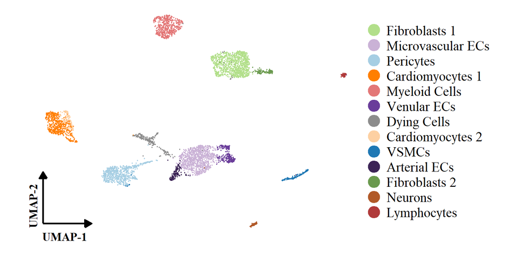

```r
Dimplot <- DimPlot(
                  Cold_Preserve_Heart_filtered,
                  reduction = "umap.integrated",
                  group.by = "cell.annotation",
                  label = F,
                  cols = cell_identity_colors,
                  pt.size = 0.1) +

  guides(color = guide_legend(override.aes = list(size=6), ncol=1)) +

  # Arrows
  geom_segment(aes(x=-14, y=-14, xend=-9, yend=-14), linewidth = 1, arrow = arrow(length=unit(0.3, 'cm'),  type = "closed")) +
  geom_segment(aes(x=-14, y=-14, xend=-14, yend=-7), linewidth = 1, arrow = arrow(length=unit(0.3, 'cm'), type = "closed")) +

  #Labels
  labs(x = "UMAP-1",
       y = "UMAP-2") +
  theme_void() +
  theme(
    aspect.ratio = 1/1.43,
    plot.title = element_blank(),
    axis.title.x = element_text(hjust = 0.05, vjust = 3.25, face = "bold", family = "serif", size = rel(1.2)),
    axis.title.y = element_text(hjust = 0.05, vjust = -4, angle=90, face = "bold", family = "serif", size = rel(1.2)),
    legend.text = element_text(family = "serif", size = rel(1.4)))

Dimplot
```

#### Treatment

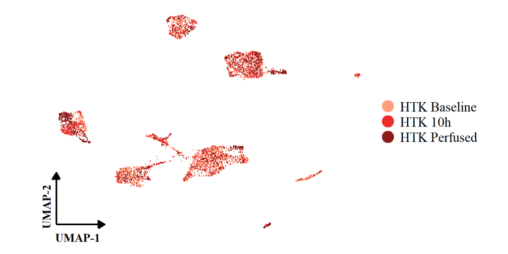

```r
Dimplot <- DimPlot(
                  Cold_Preserve_Heart_filtered,
                  reduction = "umap.integrated",
                  group.by = "Treatment",
                  label = F,
                  cols = treatment_colors,
                  pt.size = 0.1) +

  guides(color = guide_legend(override.aes = list(size=6), ncol=1)) +

  # Arrows
  geom_segment(aes(x=-14, y=-14, xend=-9, yend=-14), linewidth = 1, arrow = arrow(length=unit(0.3, 'cm'),  type = "closed")) +
  geom_segment(aes(x=-14, y=-14, xend=-14, yend=-7), linewidth = 1, arrow = arrow(length=unit(0.3, 'cm'), type = "closed")) +

  #Labels
  labs(x = "UMAP-1",
       y = "UMAP-2") +
  theme_void() +
  theme(
    aspect.ratio = 1/1.43,
    plot.title = element_blank(),
    axis.title.x = element_text(hjust = 0.05, vjust = 3.25, face = "bold", family = "serif", size = rel(1.2)),
    axis.title.y = element_text(hjust = 0.05, vjust = -4, angle=90, face = "bold", family = "serif", size = rel(1.2)),
    legend.text = element_text(family = "serif", size = rel(1.4)))

Dimplot
```

### Supplemental Figure 1A: Cell-type Marker Expression

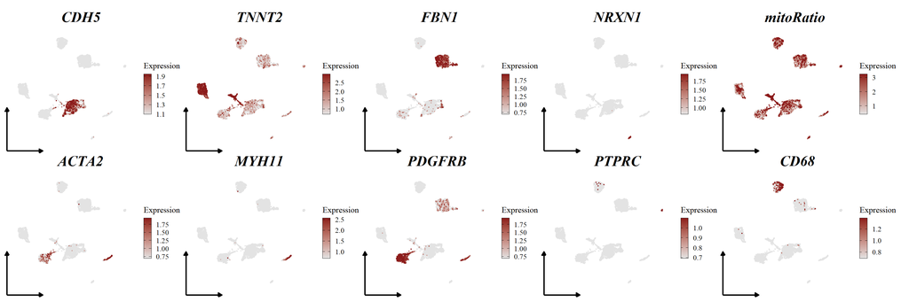

```r
DefaultAssay(Cold_Preserve_Heart_filtered) <- "SCT"

features.markers <- c("CDH5", "TNNT2", "FBN1", "NRXN1", "mitoRatio", "ACTA2", "MYH11", "PDGFRB", "PTPRC", "CD68")

FeaturePlot_Cell_Markers <- FeaturePlot(Cold_Preserve_Heart_filtered, reduction = "umap.integrated", features = features.markers, order = T, cols = c("gray89", "firebrick4"), min.cutoff = ("q30"), max.cutoff = ("q90"), combine = F)

for(i in 1:length(FeaturePlot_Cell_Markers)) {
  FeaturePlot_Cell_Markers[[i]] <- FeaturePlot_Cell_Markers[[i]] +
    guides(color = guide_colorbar(
      title = "Expression",          # legend title = gene name
      barwidth = 0.75, barheight = 4,          # adjust size
      frame.colour = "black", frame.linewidth = 0.1,
      ticks = TRUE, ticks.colour = "black"
    )) +
  theme(plot.title = element_text(hjust = 0.6, face = "bold.italic", family = "serif", size = rel(1.5)),
        axis.ticks = element_blank(),
        axis.text = element_blank(),
        axis.title = element_blank(),
        axis.line = element_blank(),
        legend.title = element_text(family = "serif", size = 12),
        legend.text = element_text(family = "serif", size = 10))

  FeaturePlot_Cell_Markers[[i]] <-  ggdraw() +
  draw_plot(FeaturePlot_Cell_Markers[[i]]) +
  geom_segment(aes(x=0, y=0, xend=0.2, yend=0), arrow = arrow(length=unit(0.2, 'cm'), type = "closed"), lwd = 1) +
  geom_segment(aes(x=0, y=0, xend=0, yend=0.3), arrow = arrow(length=unit(0.2, 'cm'), type = "closed"), lwd = 1)

}

FeaturePlot_Cell_Markers <- cowplot::plot_grid(plotlist = FeaturePlot_Cell_Markers, ncol = 5) + theme(plot.margin = margin(10, 10, 10, 10))
FeaturePlot_Cell_Markers
```

# Endothelial Cells

As stated in the Summary, this study’s central question concerns gene expression regulation in endothelial cells during cold storage and reperfusion. The remainder of this report therefore focuses specifically on the three endothelial subtypes identified above — Arterial, Microvascular, and Venular ECs — re-analyzed as an isolated subset so that downstream visualizations and differential expression testing are not diluted by the other 10 non-endothelial populations.

## Subset Endothelial cells

```r
Idents(Cold_Preserve_Heart_filtered) <- "cell.annotation"
Endothelial_Cells <- subset(Cold_Preserve_Heart_filtered, idents = c("Arterial ECs", "Microvascular ECs", "Venular ECs"))
```

### Figure 1B: UMAP of Endothelial Cell Clusters

The three endothelial subtypes are visualized independently of the full-heart UMAP above (Figure 1A), re-plotted here on the same Harmony-integrated embedding but cropped to the region occupied by endothelial nuclei, and colored first by cell type and then by treatment to assess whether storage/reperfusion shifts the balance of EC subtypes or induces distinct transcriptional states within a subtype.

#### Cell Type

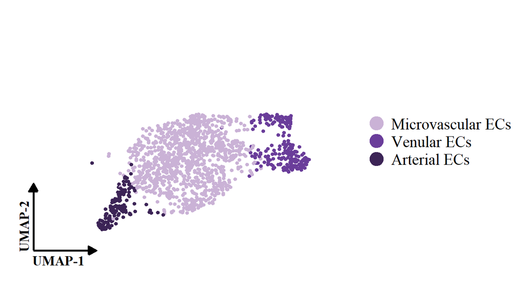

```r
Idents(Endothelial_Cells) <- Endothelial_Cells$cell.annotation
Dimplot <- DimPlot(Endothelial_Cells,
                   reduction = "umap.integrated",
                   label = F,
                   cols = cell_identity_colors,
                   pt.size = 1.25) +
  scale_y_continuous(limits = c(-9, 0)) +
  scale_x_continuous(limits = c(-3, 7)) +

  guides(color = guide_legend(override.aes = list(size=6), ncol=1)) +

  # Arrows
  geom_segment(aes(x=-3,
                   y=-9,
                   xend=-1,
                   yend=-9),
               linewidth = 1,
               arrow = arrow(length=unit(0.3, 'cm'),
                             type = "closed")) +

  geom_segment(aes(x=-3,
                   y=-9,
                   xend=-3,
                   yend=-6.25),
               linewidth = 1,
               arrow = arrow(length=unit(0.3, 'cm'),
                             type = "closed")) +

  #Labels
  labs(x = "UMAP-1",
       y = "UMAP-2") +
  theme_void() +
  theme(
    aspect.ratio = 1/1.43,
    plot.title = element_blank(),
    axis.title.x = element_text(hjust = 0.05,
                                vjust = 3.25,
                                face = "bold",
                                family = "serif",
                                size = rel(1.2)),
    axis.title.y = element_text(hjust = 0.05,
                                vjust = -4,
                                angle=90,
                                face = "bold",
                                family = "serif",
                                size = rel(1.2)),
    legend.text = element_text(family = "serif",
                               size = rel(1.4)))

Dimplot
```

#### Treatment

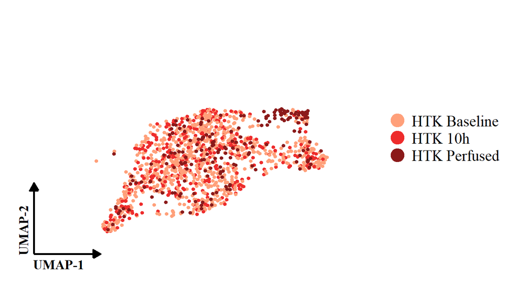

```r
Idents(Endothelial_Cells) <- Endothelial_Cells$Treatment
Dimplot <- DimPlot(Endothelial_Cells,
                   reduction = "umap.integrated",
                   label = F,
                   cols = treatment_colors,
                   pt.size = 1.25) +
  scale_y_continuous(limits = c(-9, 0)) +
  scale_x_continuous(limits = c(-3, 7)) +

  guides(color = guide_legend(override.aes = list(size=6), ncol=1)) +

  # Arrows
  geom_segment(aes(x=-3,
                   y=-9,
                   xend=-1,
                   yend=-9),
               linewidth = 1,
               arrow = arrow(length=unit(0.3, 'cm'),
                             type = "closed")) +

  geom_segment(aes(x=-3,
                   y=-9,
                   xend=-3,
                   yend=-6.25),
               linewidth = 1,
               arrow = arrow(length=unit(0.3, 'cm'),
                             type = "closed")) +

  #Labels
  labs(x = "UMAP-1",
       y = "UMAP-2") +
  theme_void() +
  theme(
    aspect.ratio = 1/1.43,
    plot.title = element_blank(),
    axis.title.x = element_text(hjust = 0.05,
                                vjust = 3.25,
                                face = "bold",
                                family = "serif",
                                size = rel(1.2)),
    axis.title.y = element_text(hjust = 0.05,
                                vjust = -4,
                                angle=90,
                                face = "bold",
                                family = "serif",
                                size = rel(1.2)),
    legend.text = element_text(family = "serif",
                               size = rel(1.4)))

Dimplot
```

### Supplemental Figure 1B: Endothelial Marker Expression

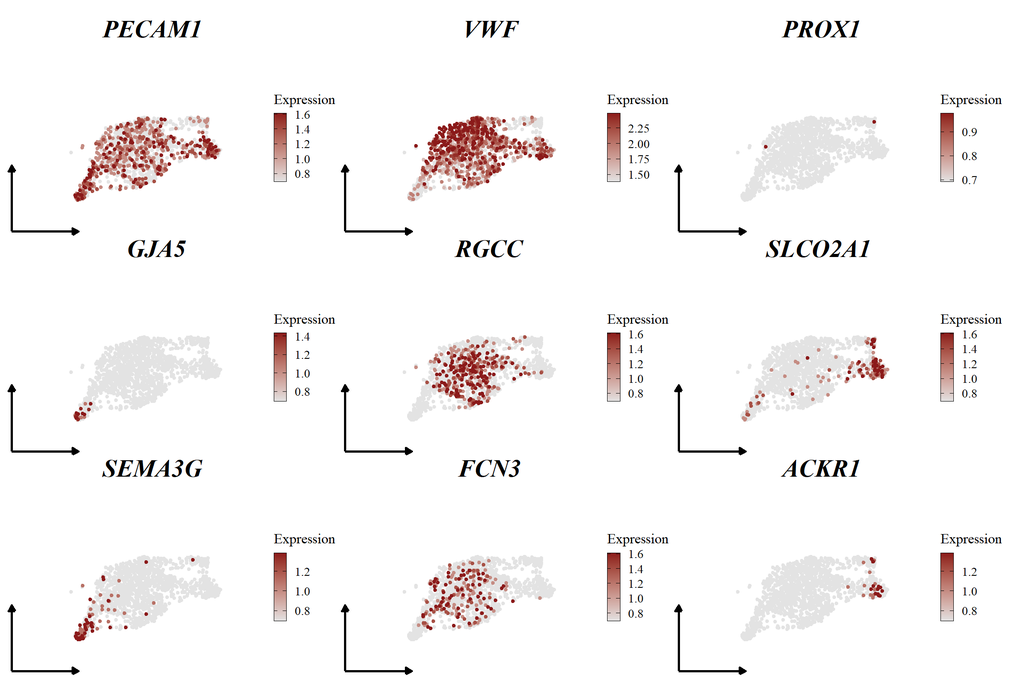

```r
DefaultAssay(Endothelial_Cells) <- "SCT"

features.markers <- c("PECAM1", "VWF", "PROX1", "GJA5", "RGCC", "SLCO2A1", "SEMA3G", "FCN3", "ACKR1")

FeaturePlot_Cell_Markers <- FeaturePlot(Endothelial_Cells,
                                        reduction = "umap.integrated",
                                        features = features.markers,
                                        order = T,
                                        cols = c("gray89", "firebrick4"),
                                        min.cutoff = ("q30"),
                                        max.cutoff = ("q90"),
                                        combine = F)

for(i in 1:length(FeaturePlot_Cell_Markers)) {
  FeaturePlot_Cell_Markers[[i]] <- FeaturePlot_Cell_Markers[[i]] +
    scale_y_continuous(limits = c(-9, 0)) +
    scale_x_continuous(limits = c(-3, 7)) +
    guides(color = guide_colorbar(
      title = "Expression",          # legend title = gene name
      barwidth = 0.75, barheight = 4,          # adjust size
      frame.colour = "black", frame.linewidth = 0.1,
      ticks = TRUE, ticks.colour = "black"
    )) +
  theme(plot.title = element_text(hjust = 0.6, face = "bold.italic", family = "serif", size = rel(1.5)),
        axis.ticks = element_blank(),
        axis.text = element_blank(),
        axis.title = element_blank(),
        axis.line = element_blank(),
        legend.title = element_text(family = "serif", size = 12),
        legend.text = element_text(family = "serif", size = 10))

  FeaturePlot_Cell_Markers[[i]] <-  ggdraw() +
  draw_plot(FeaturePlot_Cell_Markers[[i]]) +
  geom_segment(aes(x=0, y=0, xend=0.2, yend=0), arrow = arrow(length=unit(0.2, 'cm'), type = "closed"), lwd = 1) +
  geom_segment(aes(x=0, y=0, xend=0, yend=0.3), arrow = arrow(length=unit(0.2, 'cm'), type = "closed"), lwd = 1)

}

FeaturePlot_Cell_Markers <- cowplot::plot_grid(plotlist = FeaturePlot_Cell_Markers, ncol = 3) + theme(plot.margin = margin(10, 10, 10, 10))
FeaturePlot_Cell_Markers
```

### Figure 1C: DotPlot of EC Markers

```r
Endothelial_Cells$cell.annotation <- factor(Endothelial_Cells$cell.annotation, levels = c("Venular ECs", "Microvascular ECs", "Arterial ECs"))
```

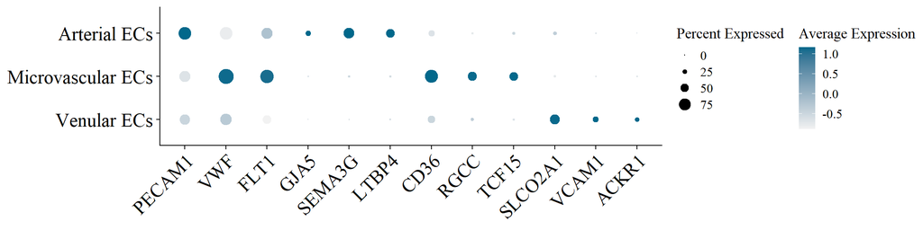

```r
Idents(Endothelial_Cells) <- "cell.annotation"
DefaultAssay(Endothelial_Cells) <- "SCT"
features.markers <- c("PECAM1", "VWF", "FLT1", "GJA5", "SEMA3G", "LTBP4", "CD36", "RGCC", "TCF15", "SLCO2A1", "VCAM1", "ACKR1")

Dotplot <- DotPlot(Endothelial_Cells, features = features.markers, cols = c("gray95", "deepskyblue4")) +
  theme(axis.title = element_blank(),
        axis.text.x = element_text(family = "serif",
                                   angle = 45,
                                   vjust = 1,
                                   hjust = 1,
                                   size = 18),
        axis.text.y = element_text(family = "serif",
                                   size = 18),
        legend.text = element_text(family = "serif"),
        legend.title = element_text(family = "serif"),
        legend.position = "right",
        legend.box = "horizontal",
        legend.margin = margin(t = 2)
        )

Dotplot
```

### Supplemental Figure 1C: Supplemental Figure 1C: Endothelial Subtype Composition by Treatment

This table reports the number and proportion of each endothelial subtype within each treatment group, to assess whether cold storage or reperfusion shifts the relative abundance of arterial, microvascular, or venular endothelium (as opposed to — or in addition to — shifting gene expression within a given subtype). The corresponding bar graph for the manuscript figure was generated externally in GraphPad Prism using the values in this table.

```r
ec_annotation_tbl <- as.data.frame(table(Endothelial_Cells$Treatment, Endothelial_Cells$cell.annotation)) %>%
  dplyr::rename(Treatment = Var1, Cell_Type = Var2, nCells = Freq) %>%
  group_by(Treatment) %>%
  mutate(Percent = round(100 * nCells / sum(nCells), 1)) %>%
  ungroup() %>%
  tidyr::pivot_wider(
    id_cols = Treatment,
    names_from = Cell_Type,
    values_from = c(nCells, Percent),
    values_fill = 0
  )

### Reorder columns so each cell type's n and % sit next to each other
cell_types <- levels(factor(Endothelial_Cells$cell.annotation))
col_order <- c("Treatment", as.vector(rbind(paste0("nCells_", cell_types), paste0("Percent_", cell_types))))
ec_annotation_tbl <- ec_annotation_tbl[, col_order]

ec_annotation_tbl %>%
  kbl(caption = "Endothelial Cell Subtype Composition by Treatment (Supplemental Figure 1C)",
      col.names = c("Treatment", rep(c("n", "%"), length(cell_types))),
      align = "c",
      row.names = FALSE) %>%
  kable_styling(bootstrap_options = c("striped", "hover", "condensed"),
                full_width = FALSE, position = "left") %>%
  row_spec(0, bold = TRUE, color = "white", background = "#4A4A4A") %>%
  add_header_above(setNames(rep(2, length(cell_types)), cell_types) %>% c(" " = 1, .)) %>%
  footnote(
    general = "Percentages reflect the proportion of each endothelial subtype within each treatment group (rows sum to 100%).",
    general_title = "Note: ", footnote_as_chunk = TRUE
  )
```

Endothelial Cell Subtype Composition by Treatment (Supplemental Figure 1C)

| Treatment | Venular ECs n | Venular ECs % | Microvascular ECs n | Microvascular ECs % | Arterial ECs n | Arterial ECs % |
| --- | --- | --- | --- | --- | --- | --- |
| HTK Baseline | 131 | 15.4 | 623 | 73.1 | 98 | 11.5 |
| HTK 10h | 46 | 11.7 | 299 | 76.3 | 47 | 12.0 |
| HTK Perfused | 69 | 33.8 | 122 | 59.8 | 13 | 6.4 |

Note: Percentages reflect the proportion of each endothelial subtype within each treatment group (rows sum to 100%).

### Supplemental Figure 1D: Heatmap of EC Markers

To complement the hypothesis-driven zonation markers in Figure 1C, an unbiased marker search (`FindAllMarkers`, RNA assay, positive markers only) is run across the three EC subtypes, and the top markers per subtype (log2FC > 1, up to 15 genes) are visualized as a heatmap of scaled expression across individual nuclei. This provides an unbiased check that the arterial/microvascular/venular distinction is supported by many genes beyond the small canonical panel used above.

```r
Idents(Endothelial_Cells) <- "cell.annotation"
DefaultAssay(Endothelial_Cells) <- "RNA"

### Join the split RNA layers — required before any DE test, even when
### the DefaultAssay is SCT, since FindMarkers/FindAllMarkers still
### references the underlying RNA layers internally
Endothelial_Cells[["RNA"]] <- JoinLayers(Endothelial_Cells[["RNA"]])

Endothelial_Cells.markers <- FindAllMarkers(Endothelial_Cells, only.pos = TRUE)

Endothelial_Cells.markers %>%
    group_by(cluster) %>%
    dplyr::filter(avg_log2FC > 1) %>%
    slice_head(n = 15) %>%
    ungroup() -> top10
```

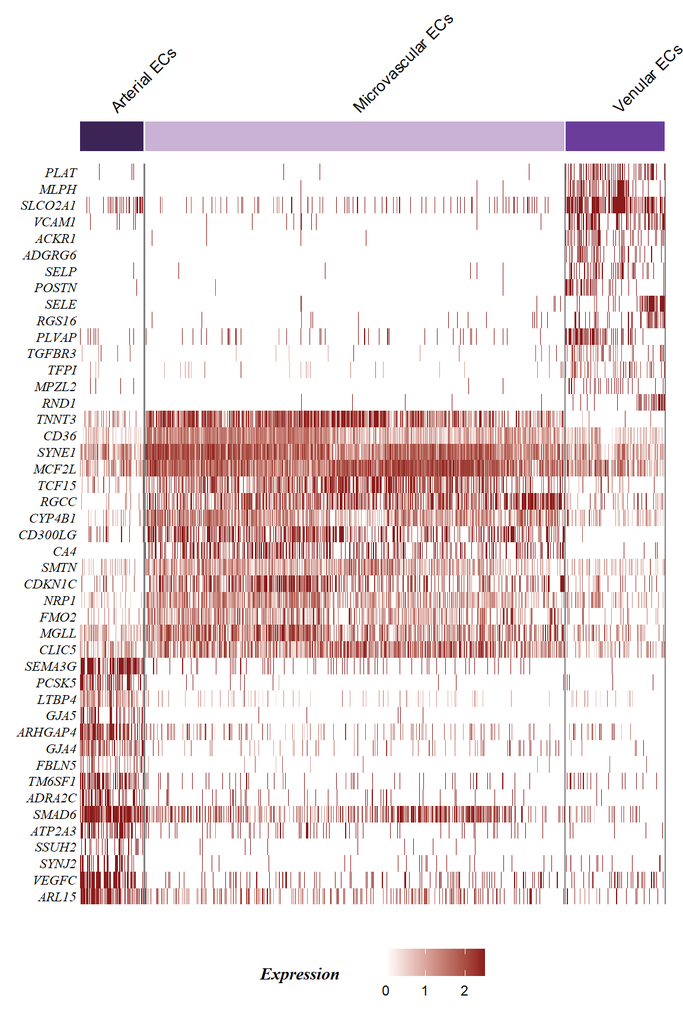

```r
DefaultAssay(Endothelial_Cells) <- "RNA"
Endothelial_Cells$cell.annotation <- factor(Endothelial_Cells$cell.annotation, levels = c("Arterial ECs", "Microvascular ECs", "Venular ECs"))

Idents(Endothelial_Cells) <- "cell.annotation"
EC_Markers_Heatmap <- DoHeatmap(Endothelial_Cells,
                                features = top10$gene,
                                group.colors = cell_identity_colors,
                                label = T,
                                size = 3.5,
                                group.bar.height = 0.04)  +
  guides(color = FALSE) +
  scale_fill_gradient2(
    low = "white",   # negative
    high = "firebrick4",        # positive
    midpoint = 0
  ) +
  theme(legend.position = "bottom",
        legend.title = element_text(color = "black",face = "bold.italic", family = "serif"),
        axis.text.y = element_text(color = "black", face = "italic", family = "serif"),
        ) +
  guides()
EC_Markers_Heatmap
```

# Differential Gene Expression

**Scope note:** the contrasts below are run specifically within the **Microvascular EC** population, reflecting this study’s focus on capillary-level endothelial dysfunction during cold storage.

## Microvascular ECs

### Cold Storage

Differentially expressed genes after cold storage compared to baseline

```r
Microvascular_10h_vs_Baseline <- run_DE_comparison(
  Endothelial_Cells,
  ident.1 = "Microvascular ECs_HTK 10h",
  ident.2 = "Microvascular ECs_HTK Baseline",
  file_path = file.path(de_output_dir, "Microvascular_Cold_Storage_UP_Baseline.csv")
)

render_DE_table(Microvascular_10h_vs_Baseline$top_table,
                 caption = "Top 20 DE Genes: Microvascular ECs, Cold Storage (10h) vs. Baseline",
                 ident1_label = "10h", ident2_label = "Baseline")
```

Top 20 DE Genes: Microvascular ECs, Cold Storage (10h) vs. Baseline

| Gene | p-value | avg log2FC | % Expr (10h) | % Expr (Baseline) | Adj. p-value |
| --- | --- | --- | --- | --- | --- |
| MT-ND4 | 0 | 2.030 | 0.9 | 0.5 | 0 |
| MT-ND4L | 0 | 1.784 | 0.8 | 0.5 | 0 |
| MT-CO3 | 0 | 1.860 | 0.8 | 0.5 | 0 |
| B2M | 0 | 1.530 | 0.8 | 0.5 | 0 |
| MT-CO2 | 0 | 1.390 | 0.9 | 0.6 | 0 |
| MT-ATP6 | 0 | 1.647 | 0.8 | 0.5 | 0 |
| MT-CYB | 0 | 1.817 | 0.7 | 0.4 | 0 |
| CAV1 | 0 | 1.323 | 0.9 | 0.6 | 0 |
| IFITM3 | 0 | 1.464 | 0.7 | 0.4 | 0 |
| TMSB4X | 0 | 1.522 | 0.8 | 0.4 | 0 |
| FABP4 | 0 | 1.501 | 0.7 | 0.4 | 0 |
| MT-ND2 | 0 | 1.658 | 0.6 | 0.3 | 0 |
| SPARCL1 | 0 | 1.138 | 0.8 | 0.6 | 0 |
| IFI27 | 0 | 1.294 | 0.7 | 0.5 | 0 |
| VIM | 0 | 1.243 | 0.7 | 0.5 | 0 |
| ACTB | 0 | 1.807 | 0.5 | 0.2 | 0 |
| IFITM2 | 0 | 2.125 | 0.5 | 0.2 | 0 |
| AQP1 | 0 | 1.317 | 0.8 | 0.6 | 0 |
| GNG11 | 0 | 1.579 | 0.5 | 0.3 | 0 |
| ACTC1 | 0 | 1.261 | 0.7 | 0.4 | 0 |

Note: Genes upregulated in 10h relative to Baseline, tested via MAST (assay = RNA). Table shows top 20 genes by adjusted p-value; full significant gene list saved to CSV.

### Perfusion

Differentially expressed genes after cold storage/perfusion compared to baseline

```r
Microvascular_Perfused_vs_Baseline <- run_DE_comparison(
  Endothelial_Cells,
  ident.1 = "Microvascular ECs_HTK Perfused",
  ident.2 = "Microvascular ECs_HTK Baseline",
  file_path = file.path(de_output_dir, "Microvascular_Perfusion_UP_Baseline.csv")
)

render_DE_table(Microvascular_Perfused_vs_Baseline$top_table,
                 caption = "Top 20 DE Genes: Microvascular ECs, Perfusion vs. Baseline",
                 ident1_label = "Perfused", ident2_label = "Baseline")
```

Top 20 DE Genes: Microvascular ECs, Perfusion vs. Baseline

| Gene | p-value | avg log2FC | % Expr (Perfused) | % Expr (Baseline) | Adj. p-value |
| --- | --- | --- | --- | --- | --- |
| HSPA1A | 0 | 8.177 | 0.8 | 0.0 | 0 |
| HSPB1 | 0 | 6.281 | 0.8 | 0.2 | 0 |
| HSPA1B | 0 | 9.310 | 0.7 | 0.0 | 0 |
| DNAJB1 | 0 | 7.770 | 0.5 | 0.0 | 0 |
| MT-ND4 | 0 | 2.572 | 0.9 | 0.5 | 0 |
| NR4A1 | 0 | 3.501 | 0.8 | 0.4 | 0 |
| B2M | 0 | 1.978 | 0.9 | 0.5 | 0 |
| MT-ATP6 | 0 | 2.428 | 0.9 | 0.5 | 0 |
| FOS | 0 | 6.796 | 0.5 | 0.0 | 0 |
| HSP90AA1 | 0 | 6.960 | 0.4 | 0.0 | 0 |
| ANXA2 | 0 | 2.996 | 0.7 | 0.3 | 0 |
| HYAL2 | 0 | 2.198 | 0.7 | 0.5 | 0 |
| ACTB | 0 | 2.679 | 0.7 | 0.2 | 0 |
| CRYAB | 0 | 2.406 | 0.7 | 0.4 | 0 |
| HSPE1 | 0 | 7.573 | 0.4 | 0.0 | 0 |
| MT-CO3 | 0 | 2.108 | 0.8 | 0.5 | 0 |
| CAV1 | 0 | 1.871 | 0.8 | 0.6 | 0 |
| HSPH1 | 0 | 7.487 | 0.4 | 0.0 | 0 |
| EMP1 | 0 | 2.577 | 0.6 | 0.3 | 0 |
| SERPINH1 | 0 | 3.059 | 0.3 | 0.3 | 0 |

Note: Genes upregulated in Perfused relative to Baseline, tested via MAST (assay = RNA). Table shows top 20 genes by adjusted p-value; full significant gene list saved to CSV.

### Perfusion versus Cold Storage

Genes upregulated after perfusion relative to cold storage (i.e., genes induced specifically by reperfusion, on top of storage).

```r
Microvascular_Perfused_vs_10h <- run_DE_comparison(
  Endothelial_Cells,
  ident.1 = "Microvascular ECs_HTK Perfused",
  ident.2 = "Microvascular ECs_HTK 10h",
  file_path = file.path(de_output_dir, "Microvascular_Perfusion_UP_Cold_Storage.csv")
)

render_DE_table(Microvascular_Perfused_vs_10h$top_table,
                 caption = "Top 20 DE Genes: Microvascular ECs, Perfusion vs. Cold Storage (10h)",
                 ident1_label = "Perfused", ident2_label = "10h")
```

Top 20 DE Genes: Microvascular ECs, Perfusion vs. Cold Storage (10h)

| Gene | p-value | avg log2FC | % Expr (Perfused) | % Expr (10h) | Adj. p-value |
| --- | --- | --- | --- | --- | --- |
| HSPA1A | 0 | 7.442 | 0.8 | 0.1 | 0 |
| HSPA1B | 0 | 7.982 | 0.7 | 0.0 | 0 |
| HSPB1 | 0 | 5.065 | 0.8 | 0.4 | 0 |
| NR4A1 | 0 | 4.182 | 0.8 | 0.3 | 0 |
| DNAJB1 | 0 | 7.363 | 0.5 | 0.1 | 0 |
| FOS | 0 | 7.175 | 0.5 | 0.0 | 0 |
| HSP90AA1 | 0 | 5.610 | 0.4 | 0.1 | 0 |
| HSPH1 | 0 | 7.401 | 0.4 | 0.0 | 0 |
| PPP1R15A | 0 | 4.318 | 0.4 | 0.1 | 0 |
| HSPE1 | 0 | 5.511 | 0.4 | 0.0 | 0 |
| DUSP1 | 0 | 2.299 | 0.7 | 0.4 | 0 |
| KLF4 | 0 | 2.061 | 0.7 | 0.4 | 0 |
| MCL1 | 0 | 1.653 | 0.6 | 0.5 | 0 |
| SERPINH1 | 0 | 3.217 | 0.3 | 0.3 | 0 |
| HYAL2 | 0 | 1.562 | 0.7 | 0.6 | 0 |
| HSPD1 | 0 | 5.521 | 0.3 | 0.1 | 0 |
| CRYAB | 0 | 1.504 | 0.7 | 0.6 | 0 |
| WNK1 | 0 | 1.376 | 0.7 | 0.6 | 0 |
| EMP1 | 0 | 1.788 | 0.6 | 0.4 | 0 |
| ANXA2 | 0 | 1.541 | 0.7 | 0.5 | 0 |

Note: Genes upregulated in Perfused relative to 10h, tested via MAST (assay = RNA). Table shows top 20 genes by adjusted p-value; full significant gene list saved to CSV.

Genes upregulated during cold storage relative to perfusion.

```r
Microvascular_10h_vs_Perfused <- run_DE_comparison(
  Endothelial_Cells,
  ident.1 = "Microvascular ECs_HTK 10h",
  ident.2 = "Microvascular ECs_HTK Perfused",
  file_path = file.path(de_output_dir, "Microvascular_Cold_Storage_UP_Perfusion.csv")
)

render_DE_table(Microvascular_10h_vs_Perfused$top_table,
                 caption = "Top 20 DE Genes: Microvascular ECs, Cold Storage (10h) vs. Perfusion",
                 ident1_label = "10h", ident2_label = "Perfused")
```

Top 20 DE Genes: Microvascular ECs, Cold Storage (10h) vs. Perfusion

| Gene | p-value | avg log2FC | % Expr (10h) | % Expr (Perfused) | Adj. p-value |
| --- | --- | --- | --- | --- | --- |
| EGFL7 | 0 | 1.890 | 0.9 | 0.7 | 0 |
| COL4A1 | 0 | 1.802 | 0.7 | 0.2 | 0 |
| MPRIP | 0 | 3.346 | 0.5 | 0.0 | 0 |
| TJP1 | 0 | 1.766 | 0.7 | 0.2 | 0 |
| KANK3 | 0 | 1.987 | 0.7 | 0.2 | 0 |
| ITPKB | 0 | 1.544 | 0.7 | 0.2 | 0 |
| SLC9A3R2 | 0 | 1.195 | 1.0 | 0.8 | 0 |
| IGFBP7 | 0 | 1.864 | 0.6 | 0.2 | 0 |
| NRP1 | 0 | 1.488 | 0.8 | 0.3 | 0 |
| PDGFB | 0 | 1.849 | 0.6 | 0.2 | 0 |
| PTPRB | 0 | 1.382 | 0.8 | 0.3 | 0 |
| C1orf21 | 0 | 2.423 | 0.5 | 0.1 | 0 |
| CDH5 | 0 | 0.994 | 0.9 | 0.6 | 0 |
| CARD10 | 0 | 1.536 | 0.6 | 0.2 | 0 |
| ZBTB46 | 0 | 2.280 | 0.5 | 0.1 | 0 |
| A2M | 0 | 1.287 | 0.8 | 0.4 | 0 |
| TNFRSF10B | 0 | 1.970 | 0.5 | 0.1 | 0 |
| CAVIN1 | 0 | 1.979 | 0.6 | 0.2 | 0 |
| UTY | 0 | 7.671 | 0.2 | 0.0 | 0 |
| TIE1 | 0 | 1.072 | 0.6 | 0.2 | 0 |

Note: Genes upregulated in 10h relative to Perfused, tested via MAST (assay = RNA). Table shows top 20 genes by adjusted p-value; full significant gene list saved to CSV.

## Microvascular Visualizations

Having identified differentially expressed genes above, the following panels visualize a targeted set of endothelial cell-cell junction genes within the Microvascular EC population specifically — motivated by the hypothesis that cold storage and reperfusion disrupt endothelial barrier integrity via junctional remodeling. The Microvascular EC population is isolated from the broader endothelial subset for these figures.

```r
DefaultAssay(Endothelial_Cells) <- "RNA"
Idents(Endothelial_Cells) <- "cell.annotation"

Microvascular <- subset(Endothelial_Cells, idents = c("Microvascular ECs"))
```

### Figure 1E: Expression of Cell Junction Genes

A curated panel of adherens junction, tight junction, and gap junction genes (e.g., `CDH5`, `CLDN5`, `TJP1`, `GJA1`) is plotted across treatment groups to assess whether junctional gene expression changes with storage duration or reperfusion status.

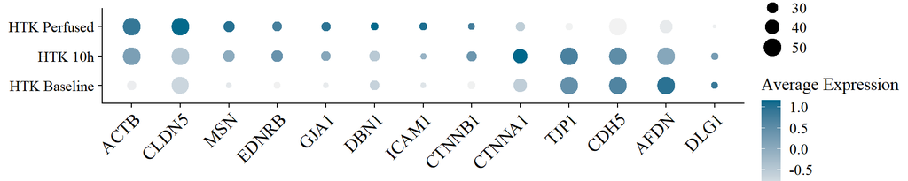

```r
Idents(Microvascular) <- "Treatment"
DefaultAssay(Microvascular) <- "RNA"
features.markers <- c( "ACTB", "CLDN5", "MSN", "EDNRB", "GJA1", "DBN1", "ICAM1", "CTNNB1", "CTNNA1", "TJP1", "CDH5", "AFDN", "DLG1")

Dotplot <- DotPlot(Microvascular, features = features.markers, cols = c("gray95", "deepskyblue4"), scale.min = 0, scale.max = 50) +
  theme(axis.title = element_blank(),
        axis.text.x = element_text(family = "serif", angle = 45, vjust = 1, hjust = 1, size = rel(1.2)),
        axis.text.y = element_text(family = "serif", size = rel(1)),
        legend.text = element_text(family = "serif"),
        legend.title = element_text(family = "serif"))

Dotplot
```

### Figure 1F: Violin Plot of Cell Junction Genes

A subset of four junction genes from Figure 1E (`CLDN5`, `GJA1`, `TJP1`, `CDH5`) is shown as per-nucleus violin plots by treatment, providing a higher-resolution view of the expression distribution — including spread and bimodality — that a dot plot’s summary statistics can obscure.

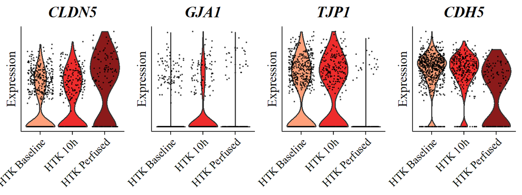

```r
features.vln <- c("CLDN5", "GJA1", "TJP1", "CDH5")
Idents(Microvascular) <- "Treatment"

VlnPlot <- VlnPlot(Microvascular, features = features.vln, cols = treatment_colors, pt.size = 0.2, alpha = 0.5, combine = F)
for(i in 1:(length(VlnPlot))) {
    VlnPlot[[i]] <- VlnPlot[[i]] +  ggtitle(features.vln[[i]]) + ylab("Expression") +
      theme(plot.title = element_text(face = "bold.italic", family = "serif", size = rel(1.2)),
            axis.title.x = element_blank(),
            axis.title.y = element_text(family = "serif", size = rel(1)),
            axis.text.x = element_text(family = "serif", size = rel(1)),
            axis.text.y = element_blank(),
            axis.ticks.y = element_blank()) +
      NoLegend()
}

VlnPlot <- cowplot::plot_grid(plotlist = VlnPlot, ncol = 4, rel_heights = c(rep(1, (length(VlnPlot)-1)), 1.5))
VlnPlot
```

### Supplemental Figure 1E: Connexin-43 and Interactors

`GJA1` (encoding Connexin-43, the primary gap junction protein in vascular endothelium) is shown alongside three of its known scaffolding/interacting partners (`DBN1`, `TJP1`, `DLG1`) to examine whether the broader Connexin-43 interactome shifts coordinately with `GJA1` itself across treatment groups.

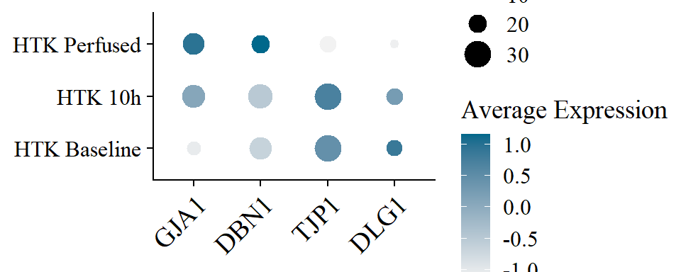

```r
Idents(Microvascular) <- "Treatment"
DefaultAssay(Microvascular) <- "RNA"
features.markers <- c("GJA1", "DBN1", "TJP1", "DLG1")

Dotplot <- DotPlot(Microvascular, features = features.markers, cols = c("gray95", "deepskyblue4"), scale.min = 0, scale.max = 30) +
  theme(axis.title = element_blank(),
        axis.text.x = element_text(family = "serif", angle = 45, vjust = 1, hjust = 1, size = rel(1.2)),
        axis.text.y = element_text(family = "serif", size = rel(1)),
        legend.text = element_text(family = "serif"),
        legend.title = element_text(family = "serif"))

Dotplot
```

# Session Info